# DEGs analysis based on estrogen group in PBMC dataset

```r
rm(list = ls())  # Removes all variables and functions from global environment
getwd()
```

```
[1] "C:/Users/ngduy/Documents/Project/Final_code/code"
```

```r
setwd("C:/Users/ngduy/Documents/Project/Final_code")
```

# Install necessary packages

```r
# BiocManager::install("tximport")
# BiocManager::install("tximportData")
# BiocManager::install("DESeq2")
# install.packages('pheatmap')
# install.packages("DOSE")
# install.packages("enrichplot")
# install.packages("ggupset")
# BiocManager::install("biomaRt")
# BiocManager::install("pathview")
```

# Load packages

```r
library(biomaRt) # BiomaRt is used to access Ensembl databases for gene annotation
library(tximport) # Import transcript-level quantification data
library(readr) # For reading data files
library(DESeq2)
library(dplyr) # for data manipulation
library(PCAtools) # PCAtools is used for PCA analysis and visualization
library(tidyverse) # includes ggplot2, for data visualisation. dplyr, for data manipulation.
library(pheatmap)
library('org.Hs.eg.db') # Annotation package for human genes
library(GEOquery) # For downloading and processing data from GEO
```

# Data import

## Import phenotype data

```r
metadata <- readxl::read_xlsx("../data/pbmc/pbmc_metadata.xlsx")
metadata <- as.data.frame(metadata)
metadata <- metadata[!is.na(metadata[[1]]),]

#Because RS10, RS15 kallisto files are missing, so we get rid of these samples in metadata
row.names(metadata) <- metadata$`RESOLVE Subject ID number`
metadata <-metadata[!row.names(metadata) %in% c("RS10","RS15"),]
head(metadata)
```

|  | RESOLVE Subject ID number | RESOLVE Screening Demographic Sex | RESOLVE AGE YEAR | RESOLVE Ethnicity | RESOLVE Day 1 Clinic SBP | RESOLVE Day 1 Clinic DBP | RESOLVE Day 1 Clinic HR | RESOLVE Day 4 Clinic DBP | RESOLVE Day 4 Clinic HR | RESOLVE Day 4 Clinic SBP | RESOLVE Screening Demographi Age | RESOLVE Screening Demographic BMI | RESOLVE Screening Demographic Height | RESOLVE Screening Demographic weight | RESOLVE Day 1 Temperature | RESOLVE Day 1 Visit date | RESOLVE Day 1 Visit time | RESOLVE Day 4 MetHb amount | RESOLVE Day 4 Temperature | RESOLVE Day 4 Visit date | RESOLVE Day 4 Visit time | RESOLVE Screening Clinic DBP | RESOLVE Screening Clinic HR | RESOLVE Screening Clinic SBP | Contraception Y/N/NA | Contraception Modality | Testosterone(nmol/L) | testosterone(ng/dL) | FSH | … |
| --- | --- | --- | --- | --- | --- | --- | --- | --- | --- | --- | --- | --- | --- | --- | --- | --- | --- | --- | --- | --- | --- | --- | --- | --- | --- | --- | --- | --- | --- | --- |
| RS08 | RS08 | Female | 22 | White | 106 | 66 | 74 | 75 | 76 | 111 | 22 | 19 | 168.0 | 55.0 | 36.3 | 2023-02-14 | 1899-12-31 09:15:00 | 0.4 | 36.2 | 2023-02-17 | 1899-12-31 09:00:00 | 71 | 73 | 115 | Y | Mirena coil | NA | NA | 2.9 | … |
| RS09 | RS09 | Female | 25 | Asian | 115 | 74 | 78 | 70 | 98 | 113 | 25 | 22 | 169.0 | 62.1 | 35.0 | 2023-02-28 | 1899-12-31 08:00:00 | 0.1 | 35.9 | 2023-03-03 | 1899-12-31 08:45:00 | 74 | 65 | 111 | Y | Copper coil | NA | NA | 7.9 | … |
| RS27 | RS27 | Female | 30 | White | 105 | 62 | 71 | 59 | 88 | 106 | 30 | 22 | 180.5 | 73.0 | 363.0 | 2023-07-03 | 1899-12-31 08:30:00 | 0.2 | 36.1 | 2023-07-06 | 1899-12-31 08:30:00 | 70 | 82 | 108 | Y | Mirena coil | NA | NA | 5.9 | … |
| RS23 | RS23 | Female | 24 | Black/African/Caribbean/Black British | 119 | 72 | 57 | 70 | 105 | 131 | 24 | 27 | 161.0 | 71.2 | 36.1 | 2023-08-21 | 1899-12-31 07:15:00 | 0.5 | 36.4 | 2023-08-24 | 1899-12-31 07:20:00 | 67 | 69 | 116 | N | NA | NA | NA | 3.9 | … |
| RS24 | RS24 | Female | 33 | White | 107 | 70 | 80 | 66 | 77 | 102 | 33 | 30 | 157.0 | 76.0 | 37.1 | 2023-09-04 | 1899-12-31 08:00:00 | 1.1 | 36.6 | 2023-09-07 | 1899-12-31 08:00:00 | 84 | 89 | 118 | Y | Copper coil | NA | NA | 4.9000000000000004 | … |
| RS33 | RS33 | Female | 22 | White | 103 | 57 | 55 | 58 | 59 | 101 | 22 | 20 | 161.0 | 53.0 | 36.3 | 2023-11-13 | 1899-12-31 08:00:00 | 0.6 | 36.8 | 2023-11-16 | 1899-12-31 08:00:00 | 62 | 69 | 102 | N | NA | NA | NA | 3.9 | … |

### Manipulate metadata to obtain necessary information

In this analysis, we use the information of estradiol level, BMI, age, so we use dplyr package to select and rename the columns we need

```r
metadata.subset <- metadata %>%
  dplyr::select(c(2,3,32,12)) %>%
  dplyr::rename(estradiol = 3,
         sex = 1,
         age = 2,
         BMI =4)
# check the data
head(metadata.subset)
```

|  | sex | age | estradiol | BMI |
| --- | --- | --- | --- | --- |
| RS08 | Female | 22 | 310.78909 | 19 |
| RS09 | Female | 25 | 146.54210 | 22 |
| RS27 | Female | 30 | 119.03141 | 22 |
| RS23 | Female | 24 | 115.76281 | 27 |
| RS24 | Female | 33 | 91.79310 | 30 |
| RS33 | Female | 22 | 66.73385 | 20 |

### Grouping samples

We will divide sample into 2 groups: high and low estradiol. Using the first quantile and third quantile to group the samples

```r
metadata.subset$group <- ""
head(metadata.subset)
```

|  | sex | age | estradiol | BMI | group |
| --- | --- | --- | --- | --- | --- |
| RS08 | Female | 22 | 310.78909 | 19 |  |
| RS09 | Female | 25 | 146.54210 | 22 |  |
| RS27 | Female | 30 | 119.03141 | 22 |  |
| RS23 | Female | 24 | 115.76281 | 27 |  |
| RS24 | Female | 33 | 91.79310 | 30 |  |
| RS33 | Female | 22 | 66.73385 | 20 |  |

```r
metadata.subset <- metadata.subset[!is.na(metadata.subset$estradiol),]
first_quantile <- quantile(metadata.subset$estradiol, probs = 0.25)
third_quantile <- quantile(metadata.subset$estradiol, probs = 0.75)
metadata.subset$group[metadata.subset$estradiol <= first_quantile] = "low"
metadata.subset$group[metadata.subset$estradiol >= third_quantile] = "high"
head(metadata.subset)
```

|  | sex | age | estradiol | BMI | group |
| --- | --- | --- | --- | --- | --- |
| RS08 | Female | 22 | 310.78909 | 19 | high |
| RS09 | Female | 25 | 146.54210 | 22 | high |
| RS27 | Female | 30 | 119.03141 | 22 | high |
| RS23 | Female | 24 | 115.76281 | 27 | high |
| RS24 | Female | 33 | 91.79310 | 30 |  |
| RS33 | Female | 22 | 66.73385 | 20 |  |

```r
# remove sample with missing value in group column
metadata.subset <- metadata.subset[metadata.subset$group!="",]
metadata.subset$group <- as.factor(metadata.subset$group)
metadata.subset
```

|  | sex | age | estradiol | BMI | group |
| --- | --- | --- | --- | --- | --- |
| RS08 | Female | 22 | 310.789094 | 19 | high |
| RS09 | Female | 25 | 146.542097 | 22 | high |
| RS27 | Female | 30 | 119.031406 | 22 | high |
| RS23 | Female | 24 | 115.762809 | 27 | high |
| RS02 | Female | 21 | 27.783074 | 22 | low |
| RS31 | Female | 25 | 17.432517 | 25 | low |
| RS21 | Female | 33 | 12.529622 | 20 | low |
| RS34 | Female | 22 | 5.175279 | 22 | low |

### check the number of samples in each group

```r
table(metadata.subset$group)
```

```
high  low
   4    4
```

## Import count data

```r
# Vector of folders of all samples
samples <- row.names(metadata.subset)
samples
```

```
[1] "RS08" "RS09" "RS27" "RS23" "RS02" "RS31" "RS21" "RS34"
```

```r
sample_folders <- paste0(samples,"_PBMC_2")
sample_folders
```

```
[1] "RS08_PBMC_2" "RS09_PBMC_2" "RS27_PBMC_2" "RS23_PBMC_2" "RS02_PBMC_2" "RS31_PBMC_2" "RS21_PBMC_2" "RS34_PBMC_2"
```

```r
# Create vector of paths to each abundance file
files <- file.path("../data/pbmc/pbmc_count_data/Kallisto abundance/PBMC",sample_folders,"abundance.tsv")
names(files) <- samples

#match transcripts and genes
tx2gene <- read.csv("../data/pbmc/pbmc_count_data/Kallisto abundance/gene_info.txt", sep="\t",header=T)
tx2gene <- tx2gene[,c(1,2)]
tx2gene
```

| ensembl_transcript_id_version | ensembl_gene_id |
| --- | --- |
| ENST00000361390.2 | ENSG00000198888 |
| ENST00000361453.3 | ENSG00000198763 |
| ENST00000361624.2 | ENSG00000198804 |
| ENST00000361739.1 | ENSG00000198712 |
| ENST00000361851.1 | ENSG00000228253 |
| ENST00000361899.2 | ENSG00000198899 |
| ENST00000362079.2 | ENSG00000198938 |
| ENST00000361227.2 | ENSG00000198840 |
| ENST00000361335.1 | ENSG00000212907 |
| ENST00000361381.2 | ENSG00000198886 |

[output cut: 990 more lines]

```r
# load the Kallisto expression estimates using tximport
txi <- tximport(files,
                type = "kallisto",
                tx2gene = tx2gene,
                ignoreTxVersion = FALSE)
```

```
Note: importing `abundance.h5` is typically faster than `abundance.tsv`
reading in files with read_tsv
1 2 3 4 5 6 7 8
summarizing abundance
summarizing counts
summarizing length
```

# Differentially expressed genes analysis

## Create DESeq2 object

```r
dds <- DESeqDataSetFromTximport(txi = txi, colData = metadata.subset, design = ~ age + BMI + group)
```

```
  the design formula contains one or more numeric variables with integer values,
  specifying a model with increasing fold change for higher values.
  did you mean for this to be a factor? if so, first convert
  this variable to a factor using the factor() function
  the design formula contains one or more numeric variables that have mean or
  standard deviation larger than 5 (an arbitrary threshold to trigger this message).
  Including numeric variables with large mean can induce collinearity with the intercept.
  Users should center and scale numeric variables in the design to improve GLM convergence.
using counts and average transcript lengths from tximport
```

```r
dds
```

```
class: DESeqDataSet
dim: 41116 8
metadata(1): version
assays(2): counts avgTxLength
rownames(41116): ENSG00000000003 ENSG00000000005 ... ENSG00000293600 ENSG00000293604
rowData names(0):
colnames(8): RS08 RS09 ... RS21 RS34
colData names(5): sex age estradiol BMI group
```

## Pre-filtering

While it is not necessary to pre-filter low count genes before running the DESeq2 functions, there are two reasons which make pre-filtering useful: by removing rows in which there are very few reads, we reduce the memory size of the dds data object, and we increase the speed of count modeling within DESeq2. It can also improve visualizations, as features with no information for differential expression are not plotted in dispersion plots or MA-plots.

Here we perform pre-filtering to keep only rows that have a count of at least 10 for a minimal number of samples. The count of 10 is a reasonable choice for bulk RNA-seq.

```r
keep <- rowSums(counts(dds) >= 10) >= 4 # keep rows with at least 10 counts in at least 4 samples (50% of cohort)
dds <- dds[keep, ]
dds
```

```
class: DESeqDataSet
dim: 15157 8
metadata(1): version
assays(2): counts avgTxLength
rownames(15157): ENSG00000000003 ENSG00000000419 ... ENSG00000293600 ENSG00000293604
rowData names(0):
colnames(8): RS08 RS09 ... RS21 RS34
colData names(5): sex age estradiol BMI group
```

## Annotation

```r
#add gene symbol and gene name
library(org.Hs.eg.db)
library(AnnotationDbi)
all_gene_id <- row.names(dds)
annotation <- AnnotationDbi::select(org.Hs.eg.db,
                     keys = all_gene_id,
                     columns = c("SYMBOL", "GENENAME", "ENTREZID"),
                     keytype = "ENSEMBL")
annotation <- annotation[!duplicated(annotation$ENSEMBL),] # remove duplicated rows based on ENSEMBL column
```

## Relevel the factor

If you never tell the DESeq2 functions which level you want to compare against(e.g. which level represents the control group), the comparisons will be based on the alphabetical order of the levels.

```r
dds$group <- relevel(dds$group, ref = "low")
```

## Run DESeq2

```r
#Differential expression analysis
dds <- DESeq(dds)
```

```
using 'avgTxLength' from assays(dds), correcting for library size
```

```r
raw_counts <- counts(dds, normalized = FALSE)
head(raw_counts)
```

```
                 RS08  RS09  RS27  RS23  RS02 RS31  RS21 RS34
ENSG00000000003     7    12     8    19    19   17    14   11
ENSG00000000419   440   389   663   557   450  493   579  544
ENSG00000000457   313   435   448   471   321  294   475  439
ENSG00000000460    55    91   109   106    51   90    96   93
ENSG00000000938 12484 10927 14106 11367 10397 9963 12477 6509
ENSG00000000971    18    36    23    39    37   74    41   21
```

```r
# Save normalized counts
normalized_counts <- counts(dds, normalized = TRUE)
head(normalized_counts)
```

```
                       RS08         RS09         RS27        RS23        RS02        RS31        RS21        RS34
ENSG00000000003    15.14962     9.861698     5.985337    21.55857    15.17628    15.77434    15.15809    9.078692
ENSG00000000419   440.69598   399.274343   607.921061   517.34748   455.87862   577.02854   537.56848  564.400736
ENSG00000000457   329.81520   411.048116   409.462815   486.29738   355.28976   321.41739   429.49630  427.023518
ENSG00000000460    73.82710    84.697246   154.813908    79.70021    67.25605    65.16063    92.33938   75.900608
ENSG00000000938 12004.86240 11644.692448 13168.497683 10269.40885 10129.18276 11636.77370 11537.43387 7157.213255
ENSG00000000971    13.53669    31.921672    25.219865    38.03820    36.34610   112.77200    35.09797   22.977463
```

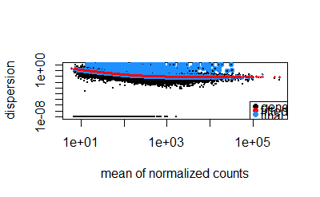

```r
write.csv(normalized_counts, file = "../result/pbmc/estrogen_normalized_counts.csv",)

DESeq2::plotDispEsts(dds)
```

```r
# summary the DEGs results
res <- results(dds,alpha=0.05)
summary(res)
```

```
out of 15157 with nonzero total read count
adjusted p-value < 0.05
LFC > 0 (up)       : 16, 0.11%
LFC < 0 (down)     : 12, 0.079%
outliers [1]       : 0, 0%
low counts [2]     : 2351, 16%
(mean count < 37)
[1] see 'cooksCutoff' argument of ?results
[2] see 'independentFiltering' argument of ?results
```

## MA plot

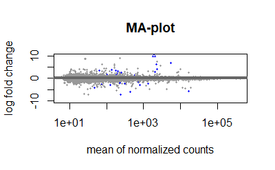

```r
DESeq2::plotMA(res, main="MA-plot", ylim=c(-10,10))
```

## Volcano plot

```r
#get results table
res.mod <- as.data.frame(res)

# add gene symbol and gene name column
res.mod$ENSEMBL <- rownames(res.mod)
res.mod <- merge(res.mod, annotation, by = "ENSEMBL", all.x = TRUE)
res.mod <- res.mod[order(res.mod$padj),] #order by adjusted p-value
res.mod <- res.mod[!is.na(res.mod$SYMBOL),] # remove rows with NA in SYMBOL column
res.mod <- res.mod[!duplicated(res.mod$SYMBOL),] # remove duplicated rows based on SYMBOL column and keep the occurrence with the lowest adjusted p-value
res.mod
```

|  | ENSEMBL | baseMean | log2FoldChange | lfcSE | stat | pvalue | padj | SYMBOL | GENENAME | ENTREZID |
| --- | --- | --- | --- | --- | --- | --- | --- | --- | --- | --- |
| 8421 | ENSG00000164308 | 1982.79348 | 3.031404967 | 0.3322016 | 9.125195678 | 7.160678e-20 | 4.584982e-16 | ERAP2 | endoplasmic reticulum aminopeptidase 2 | 64167 |
| 12995 | ENSG00000229295 | 1909.76885 | 10.040033885 | 1.0959942 | 9.160663152 | 5.157936e-20 | 4.584982e-16 | HLA-DPB1 | major histocompatibility complex, class II, DP beta 1 | 3115 |
| 13251 | ENSG00000236222 | 202.88763 | 3.190680392 | 0.4571373 | 6.979698853 | 2.958135e-12 | 1.262729e-08 | WDR46 | WD repeat domain 46 | 9277 |
| 2408 | ENSG00000105048 | 195.31950 | 2.416733071 | 0.3639782 | 6.639773331 | 3.141659e-11 | 1.005802e-07 | TNNT1 | troponin T1, slow skeletal type | 7138 |
| 13301 | ENSG00000237344 | 135.84712 | 3.666083752 | 0.6468703 | 5.667417253 | 1.449660e-08 | 3.712870e-05 | PBX2 | PBX homeobox 2 | 5089 |
| 12962 | ENSG00000228628 | 775.42808 | -2.912655753 | 0.5319138 | -5.475803806 | 4.355300e-08 | 7.967711e-05 | ATF6B | activating transcription factor 6 beta | 1388 |
| 12758 | ENSG00000223501 | 128.55393 | -2.843270488 | 0.5373133 | -5.291643212 | 1.212222e-07 | 1.940465e-04 | VPS52 | VPS52 subunit of GARP complex | 6293 |
| 14543 | ENSG00000281887 | 173.95256 | 3.417209852 | 0.6723060 | 5.082819061 | 3.718739e-07 | 5.291353e-04 | GIMAP1-GIMAP5 | GIMAP1-GIMAP5 readthrough | 100527949 |
| 8950 | ENSG00000167615 | 1309.28648 | -2.196487931 | 0.4564675 | -4.811926583 | 1.494823e-06 | 1.914270e-03 | LENG8 | leukocyte receptor cluster member 8 | 114823 |
| 12137 | ENSG00000204257 | 434.82430 | -6.084366027 | 1.3924992 | -4.369385729 | 1.245965e-05 | 1.139702e-02 | HLA-DMA | major histocompatibility complex, class II, DM alpha | 3108 |

[output cut: 990 more lines]

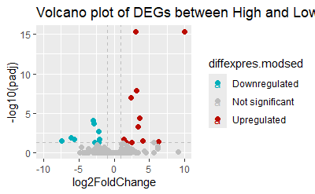

```r
#add new column indicating which genes are upregulated or downregulated or not significant
res.mod$diffexpres.modsed <- "NO"
res.mod$diffexpres.modsed[which(res.mod$padj < 0.05 & res.mod$log2FoldChange >= 1)] <- "UP"
res.mod$diffexpres.modsed[which(res.mod$padj < 0.05 & res.mod$log2FoldChange <= -1)] <- "DOWN"

# add a gene symbol column which will be used for labeling the points in the volcano plot (only differentially expres.modsed genes)
res.mod$delabel <- ifelse(res.mod$diffexpres.modsed =="UP" | res.mod$diffexpres.modsed =="DOWN", res.mod$SYMBOL, NA)

#Vocalno plot
volcano_plot <- ggplot(data = res.mod, aes(x=log2FoldChange, y=-log10(padj),color = diffexpres.modsed, label = delabel))+
  geom_vline(xintercept = c(-1, 1), col = "gray", linetype = 'dashed') +
  geom_hline(yintercept = -log10(0.05), col = "gray", linetype = 'dashed') +
  geom_point(size = 2) +
  scale_color_manual(values = c("#00AFBB", "grey", "#bb0c00"), # to set the colours of our variable<br />
                     labels = c("Downregulated", "Not significant", "Upregulated")) + # to set the labels in case we want to overwrite the categories from the dataframe
  coord_cartesian(xlim = c(-10, 10))+
  ggtitle("Volcano plot of DEGs between High and Low Estradiol level")+
  geom_text_repel(max.overlaps = Inf)
# Save the plot to a file
ggsave("../result/pbmc/img/estrogen_volcano_plot.png", plot = volcano_plot, width = 8, height = 8, dpi = 300)

# Display the plot in the document
print(volcano_plot)
```

```r
table(res.mod$diffexpres.modsed)
```

```
 DOWN    NO    UP
    9 13321    13
```

```r
write.csv(res.mod, file = "../result/pbmc/estrogen_DEGs_result.csv", row.names = TRUE) # save the results of all genes to a csv file
```

```r
significant_genes <- res.mod[!is.na(res.mod$padj) & res.mod$padj < 0.05 & (res.mod$log2FoldChange >= 1 | res.mod$log2FoldChange <= -1), ]
write.csv(significant_genes, file = "../result/pbmc/estrogen_significant_DEGs.csv", row.names = FALSE) # save the results of only significant genes to a csv file
```

## Heatmap

```r
# Create a data frame for heatmap with significant genes
df_for_heatmap <- significant_genes
df_for_heatmap$label <- ""
df_for_heatmap$label[df_for_heatmap$log2FoldChange <= -1] <- "Down"
df_for_heatmap$label[df_for_heatmap$log2FoldChange >= 1] <- "Up"
df_for_heatmap <- as.data.frame(df_for_heatmap, row.names = df_for_heatmap$ENSEMBL)
sig_genes <- rownames(df_for_heatmap)
sig_genes
```

```
 [1] "ENSG00000164308" "ENSG00000229295" "ENSG00000236222" "ENSG00000105048" "ENSG00000237344" "ENSG00000228628" "ENSG00000223501" "ENSG00000281887"
 [9] "ENSG00000167615" "ENSG00000204257" "ENSG00000228964" "ENSG00000119139" "ENSG00000232045" "ENSG00000262243" "ENSG00000196126" "ENSG00000228987"
[17] "ENSG00000089737" "ENSG00000162747" "ENSG00000206289" "ENSG00000277150" "ENSG00000288709" "ENSG00000137831"
```

```r
### Extract normalized expression for significant genes from high and low samples
norm_OEsig <- normalized_counts[sig_genes,]
head(norm_OEsig)
```

```
                     RS08       RS09       RS27       RS23        RS02        RS31       RS21        RS34
ENSG00000164308 2159.7412 4580.25677 2491.38361 4983.96855  399.233594  311.127476  338.16102  598.475583
ENSG00000229295 6905.2204 4077.47338 3924.73720  357.00294    5.478075    4.298462    0.00000    3.940355
ENSG00000236222  392.4331  408.19219  420.64435  242.59093   16.432064   61.268324   25.24796   56.292122
ENSG00000105048  117.3351  265.54798  274.75833  681.94323   35.246711   81.996029   81.08459   24.644000
ENSG00000237344  238.4500  440.01502   31.09918  298.12909   16.869981    9.629711    9.41905   43.164926
ENSG00000228628   95.8254   83.38174  695.98068   89.14192 1641.622468 1012.615904 1409.84234 1175.014179
```

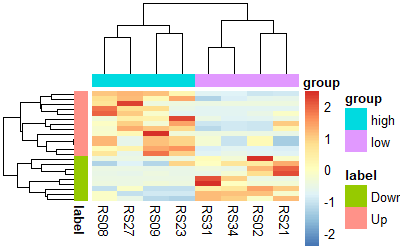

```r
# add annotation for heatmap
annotation_col = subset(metadata.subset,select = "group")
annotation_row = subset(df_for_heatmap,select = "label")

### Run pheatmap using the metadata data frame for the annotation
pheatmap(norm_OEsig,
    annotation_row = annotation_row,
    annotation_col = annotation_col,
    cluster_rows = T,
    show_rownames = F,
    border_color = NA,
    fontsize = 10,
    scale = "row",
    fontsize_row = 10,
    height = 20)
```

## Plot count of top 5 genes

### Custom plot counts of the top genes (which label of estradiol level)

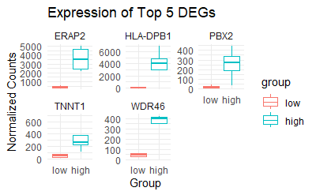

```r
library(ggplot2)
library(ggrepel)
library(dplyr)

# Get top 5 significant genes
top5_genes <- rownames(res[order(res$padj), ])[1:5]

# Combine data for all 5 genes
combined_data <- lapply(top5_genes, function(gene_id) {
  d <- plotCounts(dds, gene = gene_id, intgroup = "group", returnData = TRUE)
  d$estradiol <- metadata.subset$estradiol[match(rownames(d), rownames(metadata.subset))]
  gene_symbol <- res.mod$SYMBOL[res.mod$ENSEMBL == gene_id]
  d$gene <- gene_symbol
  return(d)
}) %>% bind_rows()

# Plot all 5 genes in one boxplot with facets
p <- ggplot(combined_data, aes(x = group, y = count, color = group)) +
  geom_boxplot(outlier.shape = NA) +
  facet_wrap(~ gene, scales = "free_y") +
  labs(title = "Expression of Top 5 DEGs", x = "Group", y = "Normalized Counts") +
  theme_minimal()

ggsave("../result/pbmc/img/boxplot_top5_genes.jpg", p, width = 10, height = 6, dpi = 300)
print(p)
```

## Exploratory analysis and visualization

### Transformations

```r
vst <- vst(dds, blind=FALSE)
head(assay(vst))
```

```
                     RS08      RS09      RS27      RS23      RS02      RS31      RS21      RS34
ENSG00000000003  6.175721  6.008923  5.852890  6.339482  6.176475  6.193186  6.175961  5.980448
ENSG00000000419  9.011541  8.890049  9.417997  9.212254  9.053602  9.351092  9.260819  9.322818
ENSG00000000457  8.659673  8.925649  8.920907  9.134315  8.748565  8.629102  8.979700  8.972573
ENSG00000000460  7.143139  7.257880  7.822868  7.206436  7.068251  7.043370  7.332724  7.165856
ENSG00000000938 13.560706 13.517049 13.693354 13.337016 13.317331 13.516074 13.503788 12.820856
ENSG00000000971  6.128733  6.554040  6.420919  6.661901  6.633158  7.513796  6.611443  6.371905
```

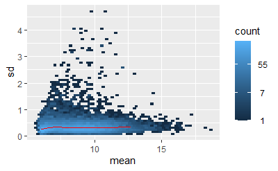

```r
library(vsn)
meanSdPlot(assay(vst), ranks = FALSE)
```

### Box-and-whisker plot

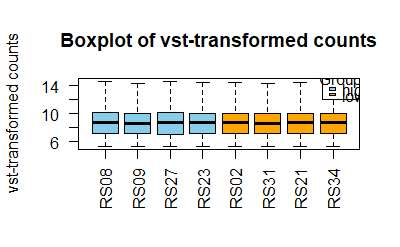

```r
# Order samples by group
sample_ordered <- metadata.subset[order(metadata.subset$group),]
sample_id_ordered <- rownames(sample_ordered)
sample_ordered$group <- as.factor(sample_ordered$group)

# Reorder rlog data
vst_ordered <- vst[, sample_id_ordered]

# Assign colors to each group
group_colors <- as.character(as.numeric(sample_ordered$group))  # 1, 2, etc.
group_colors <- c("skyblue", "orange")[as.numeric(sample_ordered$group)]  # custom colors

# Create boxplot
boxplot(assay(vst_ordered),
        col = group_colors,
        las = 2,                # rotate x-axis labels
        outline = FALSE,        # don't plot outliers
        main = "Boxplot of vst-transformed counts",
        ylab = "vst-transformed counts")

# Add legend
legend("topright",
       legend = levels(sample_ordered$group),
       fill = c("skyblue", "orange"),
       title = "Group")
```

### PCA plot

```r
p <- pca(assay(vst), metadata = metadata.subset, removeVar = 0.1)
```

```
-- removing the lower 10% of variables based on variance
```

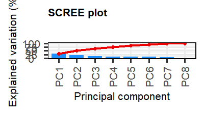

```r
screeplot(p)
```

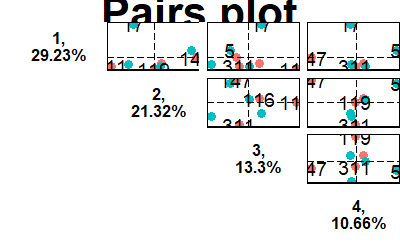

```r
pairsplot(p,
          components = c(1:4),
          triangle = TRUE,
          trianglelabSize = 12,
          hline = 0, vline = 0,
          pointSize = 3,
          gridlines.major = FALSE, gridlines.minor = FALSE,
          title = 'Pairs plot', plotaxes = FALSE,
          margingaps = unit(c(-0.01, -0.01, -0.01, -0.01), 'cm'),
          colby = 'group',
          lab = round(p$metadata$estradiol),
          labSize = 5,)
```

# Extract data of DEGs for downstream analysis

## Filter all genes with p-value < 0.05

```r
res.df <- data.frame(res)
degs_by_pvalue <- res.df[res.df$pvalue <0.05 & !is.na(res.df$pvalue),] #filter all degs with adjusted p-value < 0.05
degs_by_pvalue
```

|  | baseMean | log2FoldChange | lfcSE | stat | pvalue | padj |
| --- | --- | --- | --- | --- | --- | --- |
| ENSG00000004799 | 716.793787 | 1.0718047 | 0.2876845 | 3.725626 | 1.948312e-04 | 7.796901e-02 |
| ENSG00000004838 | 19.802022 | -1.5457407 | 0.7870806 | -1.963891 | 4.954270e-02 | NA |
| ENSG00000005379 | 346.076259 | -1.0160508 | 0.3952331 | -2.570764 | 1.014745e-02 | 9.625800e-01 |
| ENSG00000005884 | 116.516886 | -1.1892359 | 0.4272926 | -2.783188 | 5.382754e-03 | 7.106225e-01 |
| ENSG00000007516 | 153.563807 | -1.0116151 | 0.4750597 | -2.129449 | 3.321717e-02 | 9.989141e-01 |
| ENSG00000008056 | 10.686446 | 2.3645520 | 1.0366627 | 2.280927 | 2.255276e-02 | NA |
| ENSG00000012223 | 1010.097351 | -1.0923324 | 0.4035498 | -2.706810 | 6.793321e-03 | 7.981217e-01 |
| ENSG00000013725 | 3493.513113 | -0.7002443 | 0.3273715 | -2.138990 | 3.243647e-02 | 9.989141e-01 |
| ENSG00000015568 | 116.751350 | -1.2911641 | 0.5434989 | -2.375652 | 1.751798e-02 | 9.989141e-01 |
| ENSG00000038427 | 33866.183675 | 0.7474941 | 0.3541106 | 2.110906 | 3.478042e-02 | 9.989141e-01 |

[output cut: 521 more lines]

## Add gene annotation

```r
# Add Ensembl as a column to merge
degs_by_pvalue$ensembl_gene_id <- rownames(degs_by_pvalue)

# Merge annotation
annotated_degs_by_pvalue <- merge(degs_by_pvalue, annotation, by.x = "ensembl_gene_id",by.y = 'ENSEMBL', all.x = TRUE)
annotated_degs_by_pvalue
```

| ensembl_gene_id | baseMean | log2FoldChange | lfcSE | stat | pvalue | padj | SYMBOL | GENENAME | ENTREZID |
| --- | --- | --- | --- | --- | --- | --- | --- | --- | --- |
| ENSG00000004799 | 716.793787 | 1.0718047 | 0.2876845 | 3.725626 | 1.948312e-04 | 7.796901e-02 | PDK4 | pyruvate dehydrogenase kinase 4 | 5166 |
| ENSG00000004838 | 19.802022 | -1.5457407 | 0.7870806 | -1.963891 | 4.954270e-02 | NA | ZMYND10 | zinc finger MYND-type containing 10 | 51364 |
| ENSG00000005379 | 346.076259 | -1.0160508 | 0.3952331 | -2.570764 | 1.014745e-02 | 9.625800e-01 | TSPOAP1 | TSPO associated protein 1 | 9256 |
| ENSG00000005884 | 116.516886 | -1.1892359 | 0.4272926 | -2.783188 | 5.382754e-03 | 7.106225e-01 | ITGA3 | integrin subunit alpha 3 | 3675 |
| ENSG00000007516 | 153.563807 | -1.0116151 | 0.4750597 | -2.129449 | 3.321717e-02 | 9.989141e-01 | BAIAP3 | BAI1 associated protein 3 | 8938 |
| ENSG00000008056 | 10.686446 | 2.3645520 | 1.0366627 | 2.280927 | 2.255276e-02 | NA | SYN1 | synapsin I | 6853 |
| ENSG00000012223 | 1010.097351 | -1.0923324 | 0.4035498 | -2.706810 | 6.793321e-03 | 7.981217e-01 | LTF | lactotransferrin | 4057 |
| ENSG00000013725 | 3493.513113 | -0.7002443 | 0.3273715 | -2.138990 | 3.243647e-02 | 9.989141e-01 | CD6 | CD6 molecule | 923 |
| ENSG00000015568 | 116.751350 | -1.2911641 | 0.5434989 | -2.375652 | 1.751798e-02 | 9.989141e-01 | RGPD5 | RANBP2 like and GRIP domain containing 5 | 84220 |
| ENSG00000038427 | 33866.183675 | 0.7474941 | 0.3541106 | 2.110906 | 3.478042e-02 | 9.989141e-01 | VCAN | versican | 1462 |

[output cut: 521 more lines]

## Filter duplicated gene symbol

```r
annotated_degs_by_pvalue <- annotated_degs_by_pvalue %>%
  arrange(pvalue) %>% # Order by p-value in ascending order
  filter(SYMBOL != "") %>% # Filter out rows where the SYMBOL is an empty string
  distinct(SYMBOL, .keep_all = TRUE) %>% # Remove duplicate rows based on the SYMBOL column, keeping the first one which is the one with the lowest p-value
  filter(!is.na(ensembl_gene_id)) # Filter out rows where the ensembl_gene_id is NA
annotated_degs_by_pvalue
```

| ensembl_gene_id | baseMean | log2FoldChange | lfcSE | stat | pvalue | padj | SYMBOL | GENENAME | ENTREZID |
| --- | --- | --- | --- | --- | --- | --- | --- | --- | --- |
| ENSG00000229295 | 1909.768845 | 10.0400339 | 1.0959942 | 9.160663 | 5.157936e-20 | 4.584982e-16 | HLA-DPB1 | major histocompatibility complex, class II, DP beta 1 | 3115 |
| ENSG00000164308 | 1982.793476 | 3.0314050 | 0.3322016 | 9.125196 | 7.160678e-20 | 4.584982e-16 | ERAP2 | endoplasmic reticulum aminopeptidase 2 | 64167 |
| ENSG00000236222 | 202.887630 | 3.1906804 | 0.4571373 | 6.979699 | 2.958135e-12 | 1.262729e-08 | WDR46 | WD repeat domain 46 | 9277 |
| ENSG00000105048 | 195.319502 | 2.4167331 | 0.3639782 | 6.639773 | 3.141659e-11 | 1.005802e-07 | TNNT1 | troponin T1, slow skeletal type | 7138 |
| ENSG00000237344 | 135.847116 | 3.6660838 | 0.6468703 | 5.667417 | 1.449660e-08 | 3.712870e-05 | PBX2 | PBX homeobox 2 | 5089 |
| ENSG00000228628 | 775.428079 | -2.9126558 | 0.5319138 | -5.475804 | 4.355300e-08 | 7.967711e-05 | ATF6B | activating transcription factor 6 beta | 1388 |
| ENSG00000223501 | 128.553933 | -2.8432705 | 0.5373133 | -5.291643 | 1.212222e-07 | 1.940465e-04 | VPS52 | VPS52 subunit of GARP complex | 6293 |
| ENSG00000281887 | 173.952557 | 3.4172099 | 0.6723060 | 5.082819 | 3.718739e-07 | 5.291353e-04 | GIMAP1-GIMAP5 | GIMAP1-GIMAP5 readthrough | 100527949 |
| ENSG00000167615 | 1309.286480 | -2.1964879 | 0.4564675 | -4.811927 | 1.494823e-06 | 1.914270e-03 | LENG8 | leukocyte receptor cluster member 8 | 114823 |
| ENSG00000204257 | 434.824297 | -6.0843660 | 1.3924992 | -4.369386 | 1.245965e-05 | 1.139702e-02 | HLA-DMA | major histocompatibility complex, class II, DM alpha | 3108 |

[output cut: 441 more lines]

```r
NA
```

## Extract vst transformed data for machine learning

```r
filtered_tx_id <- annotated_degs_by_pvalue$ensembl_gene_id
vst_matrix <- assay(vst)
vst_degs_by_pvalue <- vst_matrix[filtered_tx_id, ]
head(vst_degs_by_pvalue)
```

```
                     RS08      RS09      RS27      RS23      RS02      RS31      RS21      RS34
ENSG00000229295 12.769713 12.020805 11.966775  8.754348  5.828906  5.768257  5.292656  5.748185
ENSG00000164308 11.127638 12.185594 11.327092 12.305508  8.889924  8.590720  8.689413  9.397870
ENSG00000236222  8.868947  8.917095  8.954021  8.304347  6.211171  6.995746  6.421517  6.931951
ENSG00000105048  7.551023  8.406905  8.446033  9.566645  6.614055  7.230333  7.220900  6.408576
ENSG00000237344  8.285021  9.009626  6.538635  8.540696  6.222928  6.000616  5.992979  6.744569
ENSG00000228628  7.365462  7.244539  9.593176  7.301943 10.747456 10.089582 10.538385 10.290227
```

```r
vst_degs_by_pvalue <- cbind(gene_symbol = annotated_degs_by_pvalue$SYMBOL, vst_degs_by_pvalue)
write.csv(vst_degs_by_pvalue, file = "../result/pbmc/estrogen_vst_DEGs_expression_by_pvalue.csv", row.names = TRUE)
write.csv(metadata.subset, file = "../result/pbmc/estrogen_clinical_data.csv")
```

# Extract expression of all genes with symbol

```r
df_res <- as.data.frame(res)
df_res_ordered_by_pvalue <- df_res[order(df_res$pvalue),]
df_res_ordered_by_pvalue$ENSEMBL <- rownames(df_res_ordered_by_pvalue)
annotated_df_res_ordered_by_pvalue <- merge(df_res_ordered_by_pvalue,annotation,by='ENSEMBL',all.x = TRUE)
```

```r
# remove duplicated and NA values in SYMBOL column
annotated_df_res_ordered_by_pvalue <- annotated_df_res_ordered_by_pvalue %>%
  filter(!is.na(SYMBOL)) %>%
  distinct(SYMBOL, .keep_all = TRUE) %>%
  filter(!is.na(ENSEMBL))
```

```r
all_gene_id <- annotated_df_res_ordered_by_pvalue$ENSEMBL
all_vst_matrix <- vst_matrix[all_gene_id,]
```

```r
all_rld_matrix <- cbind(gene_symbol = annotated_df_res_ordered_by_pvalue$SYMBOL,all_vst_matrix)
write.csv(all_rld_matrix, file = "../result/pbmc/estrogen_vst_all_genes.csv",row.names = TRUE)
```